# Sales Volume Predictions

ALADEMEHIN OLUWATOMISIN RUTH

2025-10-27

# 1 Loading Libraries

```r
library(readr)
library(caret)
```

```r
library(ggplot2)
library(corrplot)
```

# 2 Introduction

```
Predicting sales of four different product types and Assessing the impact services reviews and customer reviews  on sales
Goals:
```

1. Predicting Sales • Predicting sales of four different product types: PC, Laptops, Netbooks and Smartphones
2. Assessing sales impact • Assessing the impact services reviews and customer reviews have on sales of different product types

# 3 Data Description

We have 80 observations and 18 variables on the existing products. one of the variable which is “ProductType” is categorical, while the rest are numerical. The data was given with the project statement as an attached file.

## 3.1 Loading dataset

```r
Sales <- read.csv("existingproductattributes2017.csv")
```

```r
summary(Sales)
```

```
##  ProductType          ProductNum        Price         x5StarReviews
##  Length:80          Min.   :101.0   Min.   :   3.60   Min.   :   0.0
##  Class :character   1st Qu.:120.8   1st Qu.:  52.66   1st Qu.:  10.0
##  Mode  :character   Median :140.5   Median : 132.72   Median :  50.0
##                     Mean   :142.6   Mean   : 247.25   Mean   : 176.2
##                     3rd Qu.:160.2   3rd Qu.: 352.49   3rd Qu.: 306.5
##                     Max.   :200.0   Max.   :2249.99   Max.   :2801.0
##
##  x4StarReviews    x3StarReviews    x2StarReviews    x1StarReviews
##  Min.   :  0.00   Min.   :  0.00   Min.   :  0.00   Min.   :   0.00
##  1st Qu.:  2.75   1st Qu.:  2.00   1st Qu.:  1.00   1st Qu.:   2.00
##  Median : 22.00   Median :  7.00   Median :  3.00   Median :   8.50
##  Mean   : 40.20   Mean   : 14.79   Mean   : 13.79   Mean   :  37.67
##  3rd Qu.: 33.00   3rd Qu.: 11.25   3rd Qu.:  7.00   3rd Qu.:  15.25
##  Max.   :431.00   Max.   :162.00   Max.   :370.00   Max.   :1654.00
##
##  PositiveServiceReview NegativeServiceReview Recommendproduct BestSellersRank
##  Min.   :  0.00        Min.   :  0.000       Min.   :0.100    Min.   :    1
##  1st Qu.:  2.00        1st Qu.:  1.000       1st Qu.:0.700    1st Qu.:    7
##  Median :  5.50        Median :  3.000       Median :0.800    Median :   27
##  Mean   : 51.75        Mean   :  6.225       Mean   :0.745    Mean   : 1126
##  3rd Qu.: 42.00        3rd Qu.:  6.250       3rd Qu.:0.900    3rd Qu.:  281
##  Max.   :536.00        Max.   :112.000       Max.   :1.000    Max.   :17502
##                                                               NA's   :15
##  ShippingWeight     ProductDepth      ProductWidth    ProductHeight
##  Min.   : 0.0100   Min.   :  0.000   Min.   : 0.000   Min.   : 0.000
##  1st Qu.: 0.5125   1st Qu.:  4.775   1st Qu.: 1.750   1st Qu.: 0.400
##  Median : 2.1000   Median :  7.950   Median : 6.800   Median : 3.950
##  Mean   : 9.6681   Mean   : 14.425   Mean   : 7.819   Mean   : 6.259
##  3rd Qu.:11.2050   3rd Qu.: 15.025   3rd Qu.:11.275   3rd Qu.:10.300
##  Max.   :63.0000   Max.   :300.000   Max.   :31.750   Max.   :25.800
##
##   ProfitMargin        Volume
##  Min.   :0.0500   Min.   :    0
##  1st Qu.:0.0500   1st Qu.:   40
##  Median :0.1200   Median :  200
##  Mean   :0.1545   Mean   :  705
##  3rd Qu.:0.2000   3rd Qu.: 1226
##  Max.   :0.4000   Max.   :11204
##
```

```r
attributes(Sales)
```

```
## $names
##  [1] "ProductType"           "ProductNum"            "Price"
##  [4] "x5StarReviews"         "x4StarReviews"         "x3StarReviews"
##  [7] "x2StarReviews"         "x1StarReviews"         "PositiveServiceReview"
## [10] "NegativeServiceReview" "Recommendproduct"      "BestSellersRank"
## [13] "ShippingWeight"        "ProductDepth"          "ProductWidth"
## [16] "ProductHeight"         "ProfitMargin"          "Volume"
##
## $class
## [1] "data.frame"
##
## $row.names
##  [1]  1  2  3  4  5  6  7  8  9 10 11 12 13 14 15 16 17 18 19 20 21 22 23 24 25
## [26] 26 27 28 29 30 31 32 33 34 35 36 37 38 39 40 41 42 43 44 45 46 47 48 49 50
## [51] 51 52 53 54 55 56 57 58 59 60 61 62 63 64 65 66 67 68 69 70 71 72 73 74 75
## [76] 76 77 78 79 80
```

```r
structure(Sales)
```

```
##         ProductType ProductNum   Price x5StarReviews x4StarReviews
## 1                PC        101  949.00             3             3
## 2                PC        102 2249.99             2             1
## 3                PC        103  399.00             3             0
## 4            Laptop        104  409.99            49            19
## 5            Laptop        105 1079.99            58            31
## 6       Accessories        106  114.22            83            30
## 7       Accessories        107  379.99            11             3
## 8       Accessories        108   65.29            33            19
## 9       Accessories        109  119.99            16             9
## 10      Accessories        110   16.99            10             1
## 11      Accessories        111    6.55            21             2
## 12      Accessories        112   15.00            75            25
## 13      Accessories        113   52.50            10             8
## 14      Accessories        114   21.08           313            62
```

[output cut: 309 more lines]

```r
names(Sales)
```

```
##  [1] "ProductType"           "ProductNum"            "Price"
##  [4] "x5StarReviews"         "x4StarReviews"         "x3StarReviews"
##  [7] "x2StarReviews"         "x1StarReviews"         "PositiveServiceReview"
## [10] "NegativeServiceReview" "Recommendproduct"      "BestSellersRank"
## [13] "ShippingWeight"        "ProductDepth"          "ProductWidth"
## [16] "ProductHeight"         "ProfitMargin"          "Volume"
```

Data Description Insight;

The dataset (existingproductattributes2017.csv) includes:

1. ProductType → categorical
2. Numerical predictors → Price, ShippingWeight, Reviews (1–5 stars), Service Reviews, Product dimensions, ProfitMargin, etc.
3. Target variable → Volume (Sales Volume)

Summary inspection showed no missing values except in BestSellersRank, which was subsequently removed.

Dummy variable encoding was applied to convert the ProductType variable into model-friendly binary indicators.

# 4 Data Preprocessing

## 4.1 Checking for duplicates

```r
duplicated(Sales)
```

```
##  [1] FALSE FALSE FALSE FALSE FALSE FALSE FALSE FALSE FALSE FALSE FALSE FALSE
## [13] FALSE FALSE FALSE FALSE FALSE FALSE FALSE FALSE FALSE FALSE FALSE FALSE
## [25] FALSE FALSE FALSE FALSE FALSE FALSE FALSE FALSE FALSE FALSE FALSE FALSE
## [37] FALSE FALSE FALSE FALSE FALSE FALSE FALSE FALSE FALSE FALSE FALSE FALSE
## [49] FALSE FALSE FALSE FALSE FALSE FALSE FALSE FALSE FALSE FALSE FALSE FALSE
## [61] FALSE FALSE FALSE FALSE FALSE FALSE FALSE FALSE FALSE FALSE FALSE FALSE
## [73] FALSE FALSE FALSE FALSE FALSE FALSE FALSE FALSE
```

# 5 Checking for missing values

```r
is.na(Sales)
```

[output not shown]

[output cut: 309 more lines]

```r
sum(is.na(Sales))
```

```
## [1] 15
```

# 6 Remove missing value variable

```r
Sales$BestSellersRank <- NULL
```

Missing Values Insights;

# 7 Checking for outliers

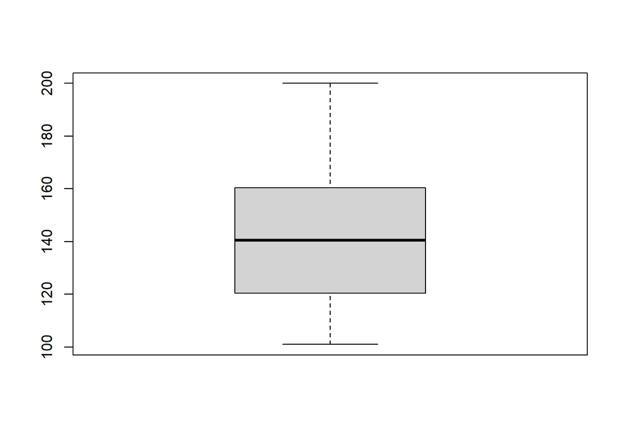

```r
boxplot(Sales$ProductNum)
```

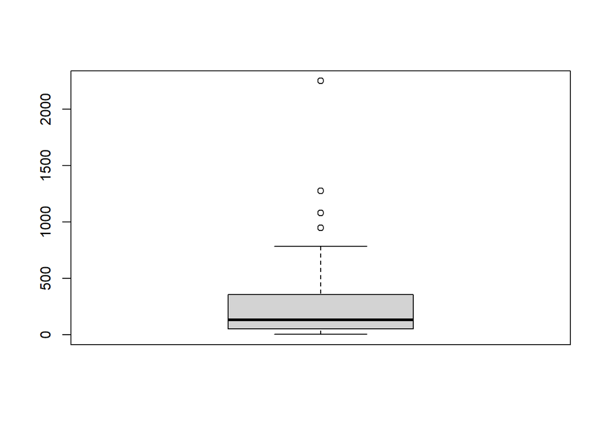

```r
boxplot(Sales$Price)
```

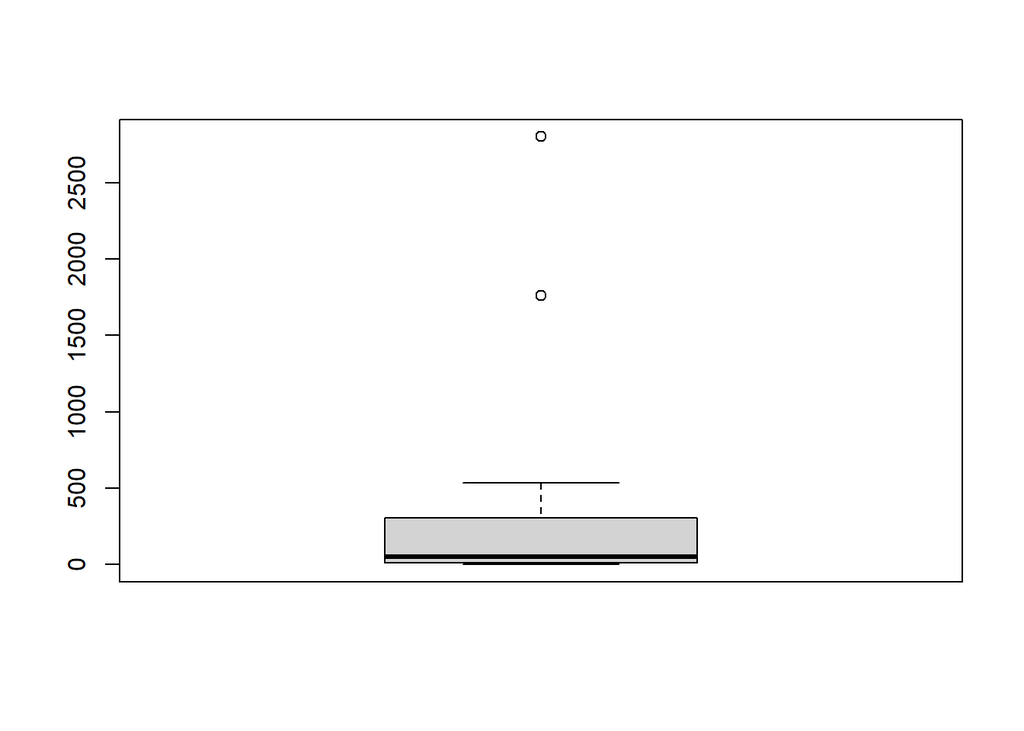

```r
boxplot(Sales$x5StarReviews)
```

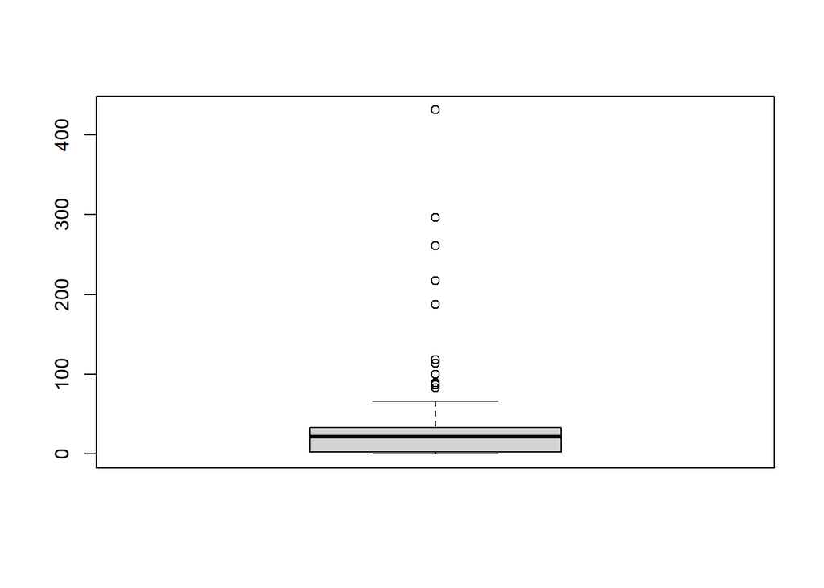

```r
boxplot(Sales$x4StarReviews)
```

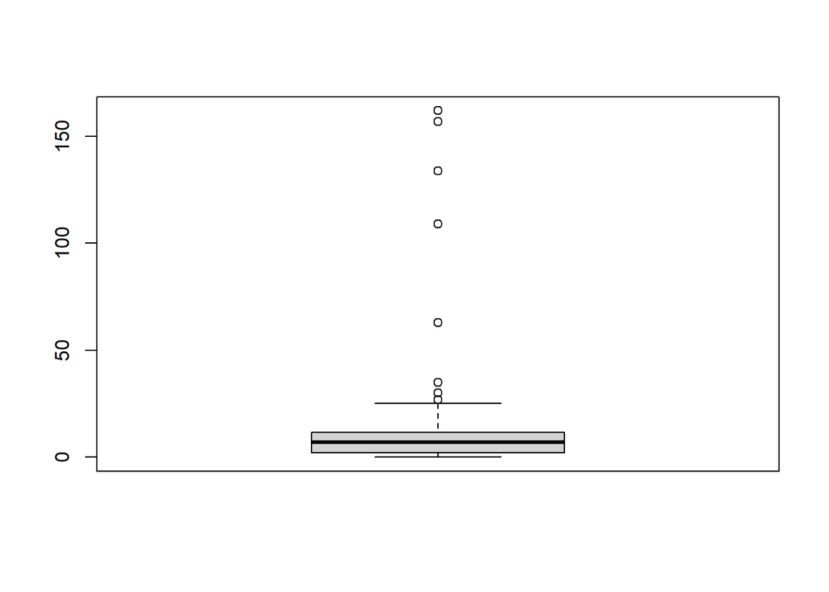

```r
boxplot(Sales$x3StarReviews)
```

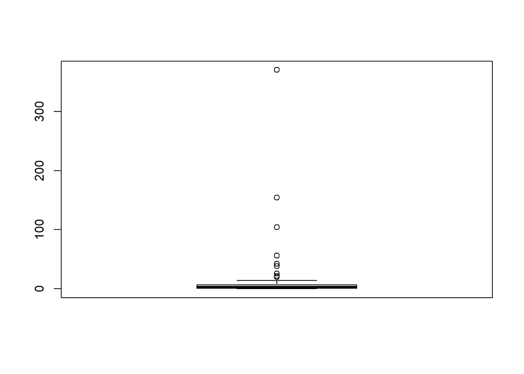

```r
boxplot(Sales$x2StarReviews)
```

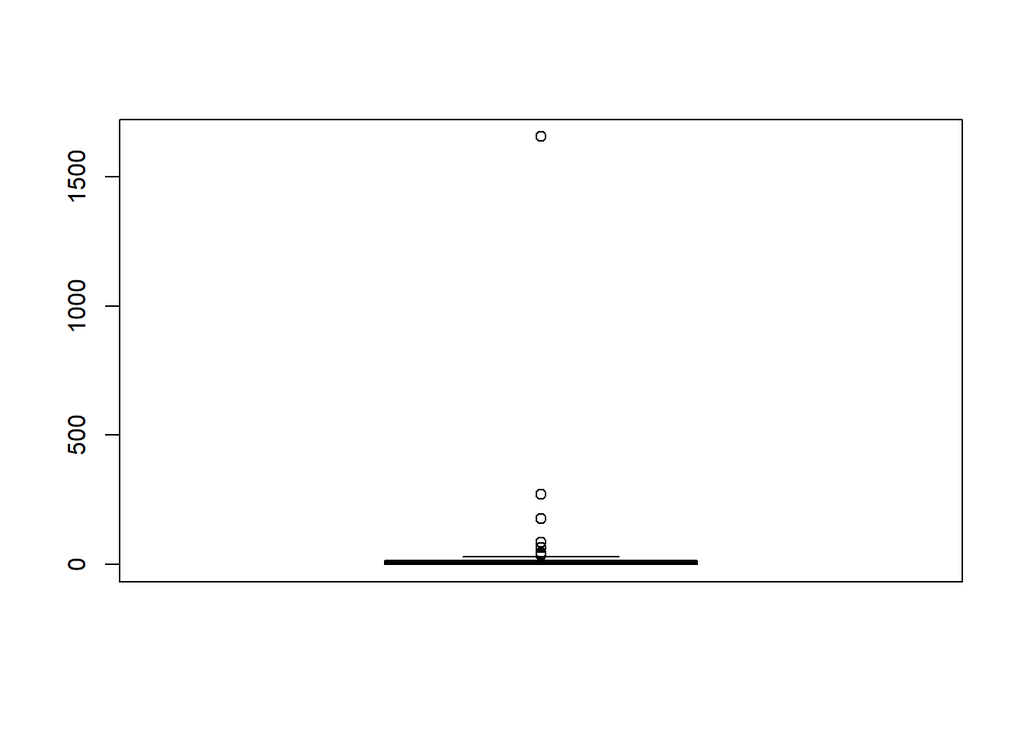

```r
boxplot(Sales$x1StarReviews)
```

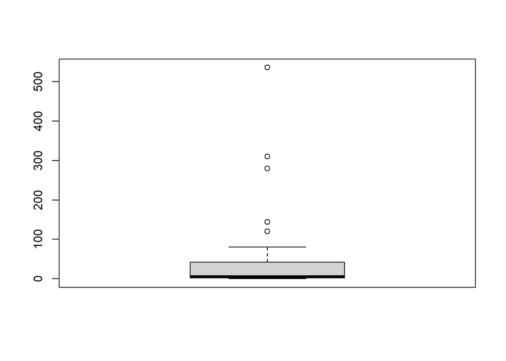

```r
boxplot(Sales$PositiveServiceReview)
```

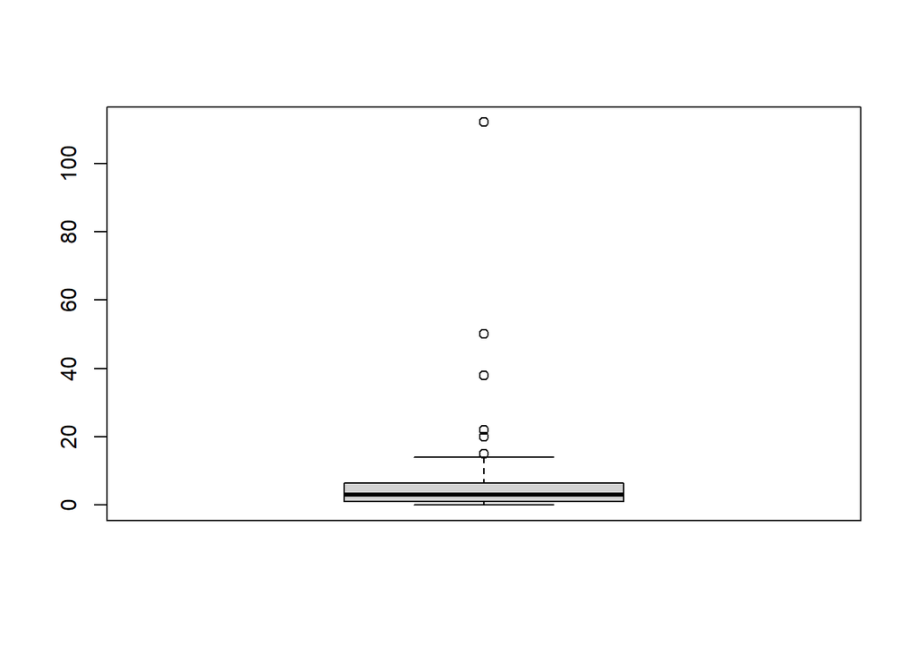

```r
boxplot(Sales$NegativeServiceReview)
```

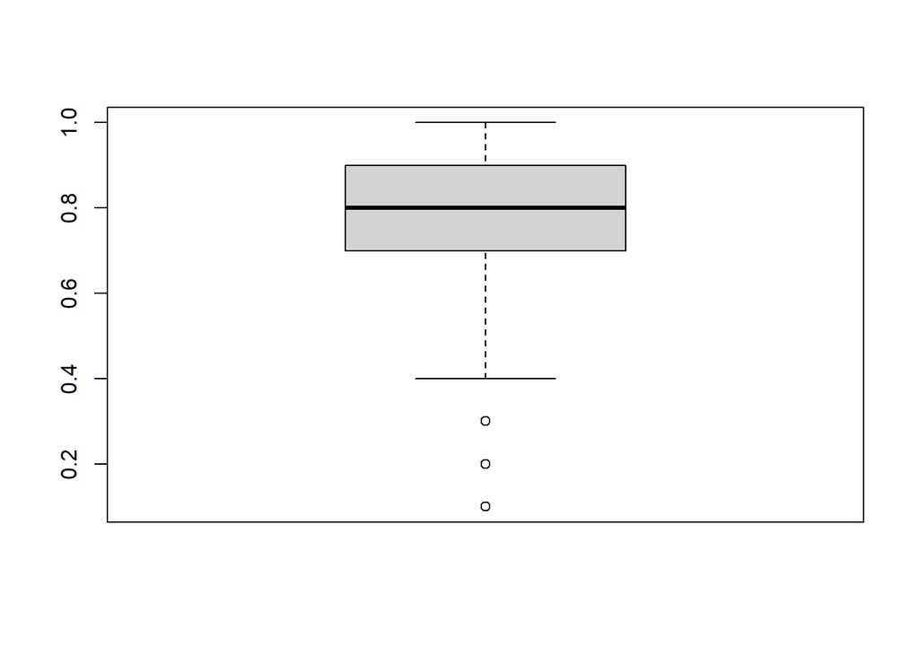

```r
boxplot(Sales$Recommendproduct)
```

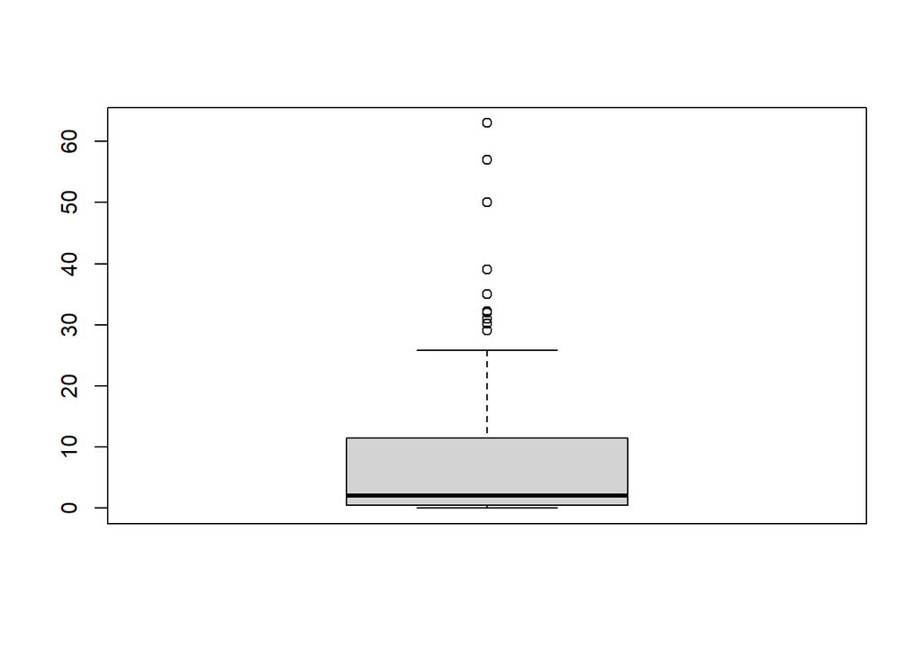

```r
boxplot(Sales$ShippingWeight)
```

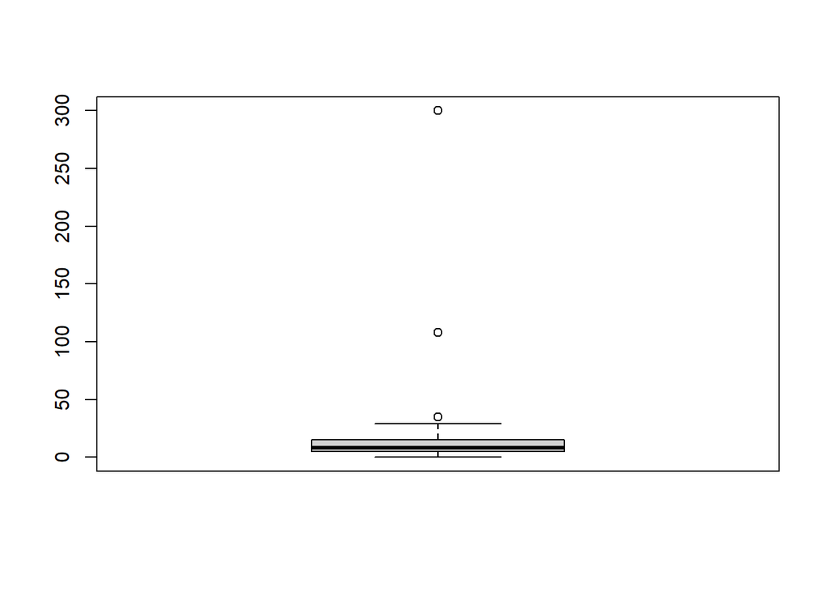

```r
boxplot(Sales$ProductDepth)
```

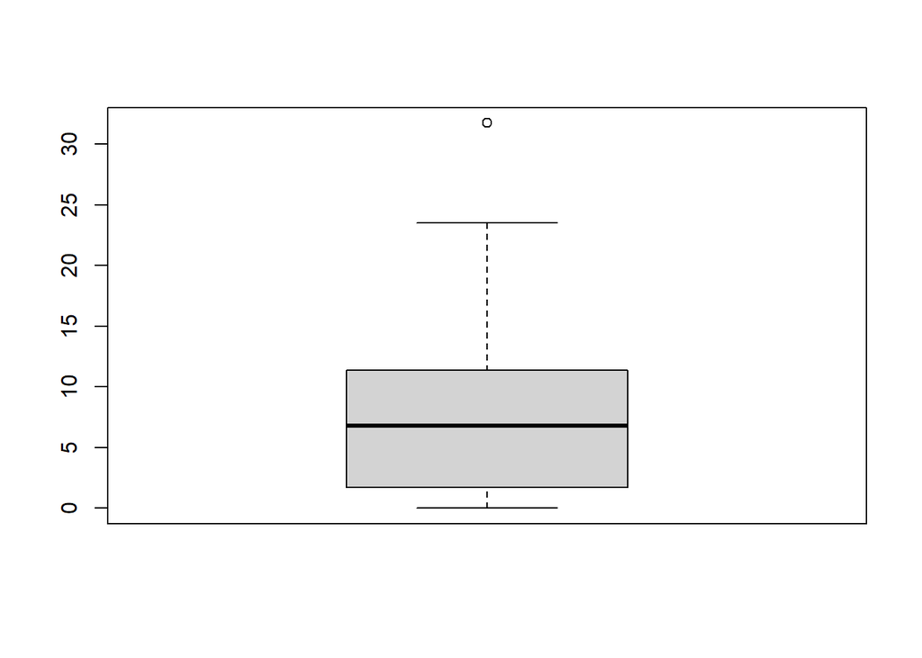

```r
boxplot(Sales$ProductWidth)
```

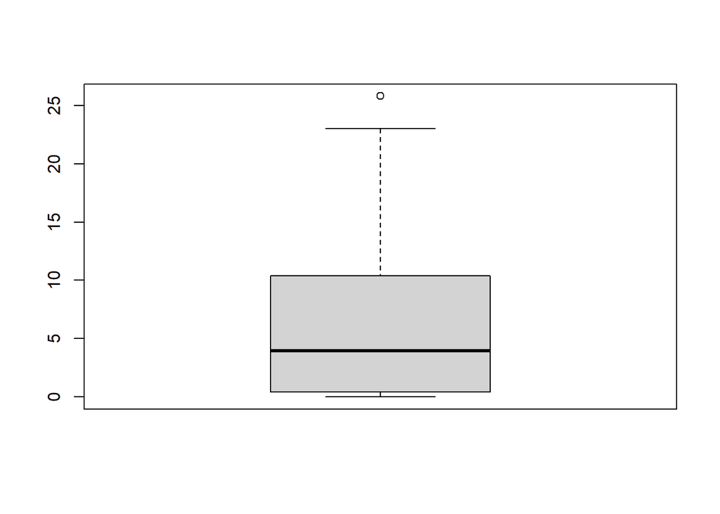

```r
boxplot(Sales$ProductHeight)
```

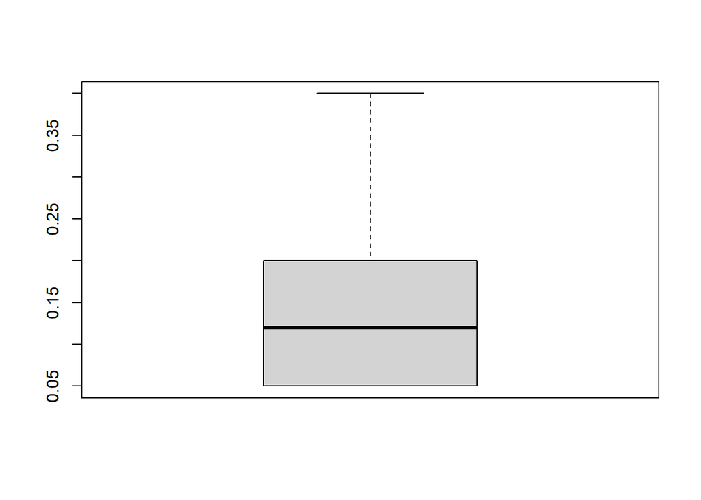

```r
boxplot(Sales$ProfitMargin)
```

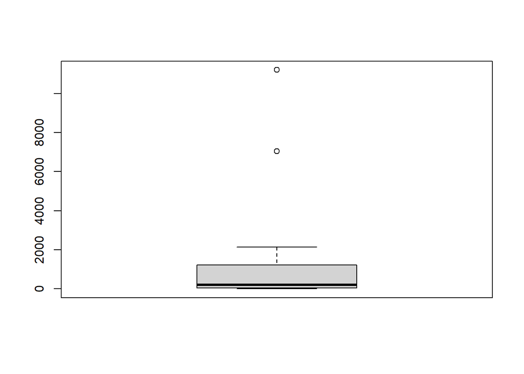

```r
boxplot(Sales$Volume)
```

Outliers Insight;

Boxplots revealed extreme values in:

1. Price
2. Review counts (1 to 5 stars)
3. Volume These are expected in sales datasets and were retained since removing them may distort real behavior.

# 8 Dummify the data

```r
length(unique(Sales$ProductType))
```

```
## [1] 12
```

```r
newDataFrame <- dummyVars(" ~ .", data = Sales)
readyData <- data.frame(predict(newDataFrame, newdata = Sales))
```

# 9 Correlation between the relevant independent variables and the dependent variable

```r
corrData <- cor(readyData)
corrData
```

```
##                             ProductTypeAccessories ProductTypeDisplay
## ProductTypeAccessories                 1.000000000        -0.17916128
## ProductTypeDisplay                    -0.179161283         1.00000000
## ProductTypeExtendedWarranty           -0.262265264        -0.09759001
## ProductTypeGameConsole                -0.111111111        -0.04134491
## ProductTypeLaptop                     -0.136963567        -0.05096472
## ProductTypeNetbook                    -0.111111111        -0.04134491
## ProductTypePC                         -0.159188978        -0.05923489
## ProductTypePrinter                    -0.291491544        -0.10846523
## ProductTypePrinterSupplies            -0.136963567        -0.05096472
## ProductTypeSmartphone                 -0.159188978        -0.05923489
## ProductTypeSoftware                   -0.197582993        -0.07352146
## ProductTypeTablet                     -0.136963567        -0.05096472
## ProductNum                            -0.338862490         0.08407390
## Price                                 -0.384906124         0.23172981
## x5StarReviews                          0.127803771        -0.03758386
## x4StarReviews                          0.156715126        -0.00293832
## x3StarReviews                          0.110608918        -0.03849540
## x2StarReviews                          0.033055555        -0.02708636
## x1StarReviews                         -0.041647041        -0.03628464
## PositiveServiceReview                  0.002699224        -0.09438421
## NegativeServiceReview                 -0.148034357        -0.01861755
## Recommendproduct                       0.058505351         0.07239820
## ShippingWeight                        -0.341367875         0.10374059
## ProductDepth                           0.191398963         0.01528395
## ProductWidth                          -0.154462467         0.28447123
## ProductHeight                         -0.060521774         0.18486593
## ProfitMargin                          -0.626935212         0.03906690
## Volume                                 0.127803771        -0.03758386
##                             ProductTypeExtendedWarranty ProductTypeGameConsole
## ProductTypeAccessories                      -0.26226526           -0.111111111
## ProductTypeDisplay                          -0.09759001           -0.041344912
## ProductTypeExtendedWarranty                  1.00000000           -0.060522753
## ProductTypeGameConsole                      -0.06052275            1.000000000
## ProductTypeLaptop                           -0.07460471           -0.031606977
## ProductTypeNetbook                          -0.06052275           -0.025641026
## ProductTypePC                               -0.08671100           -0.036735918
## ProductTypePrinter                          -0.15877684           -0.067267279
## ProductTypePrinterSupplies                  -0.07460471           -0.031606977
## ProductTypeSmartphone                       -0.08671100           -0.036735918
```

[output cut: 264 more lines]

```
## Price                         0.294160597  0.099669405 -0.142343990
## x5StarReviews                -0.160004003 -0.013448603  1.000000000
## x4StarReviews                -0.085855971 -0.146653802  0.879006394
## x3StarReviews                -0.068081406 -0.128706922  0.763373189
## x2StarReviews                -0.013774805 -0.090093715  0.487279328
## x1StarReviews                 0.002517859 -0.031227760  0.255023904
## PositiveServiceReview        -0.314294445  0.423591716  0.622260219
## NegativeServiceReview        -0.020735305  0.042035630  0.309418989
## Recommendproduct             -0.043715755  0.095760642  0.169541264
## ShippingWeight                0.700311109 -0.079215379 -0.188023980
## ProductDepth                  0.025484993 -0.207176026  0.066105249
## ProductWidth                  0.566827113 -0.291436397 -0.143436609
## ProductHeight                 1.000000000 -0.288106289 -0.160004003
## ProfitMargin                 -0.288106289  1.000000000 -0.013448603
## Volume                       -0.160004003 -0.013448603  1.000000000
```

Dummy Encoding

Using dummyVars(), all categorical variables were converted to numerical features to enable model processing.

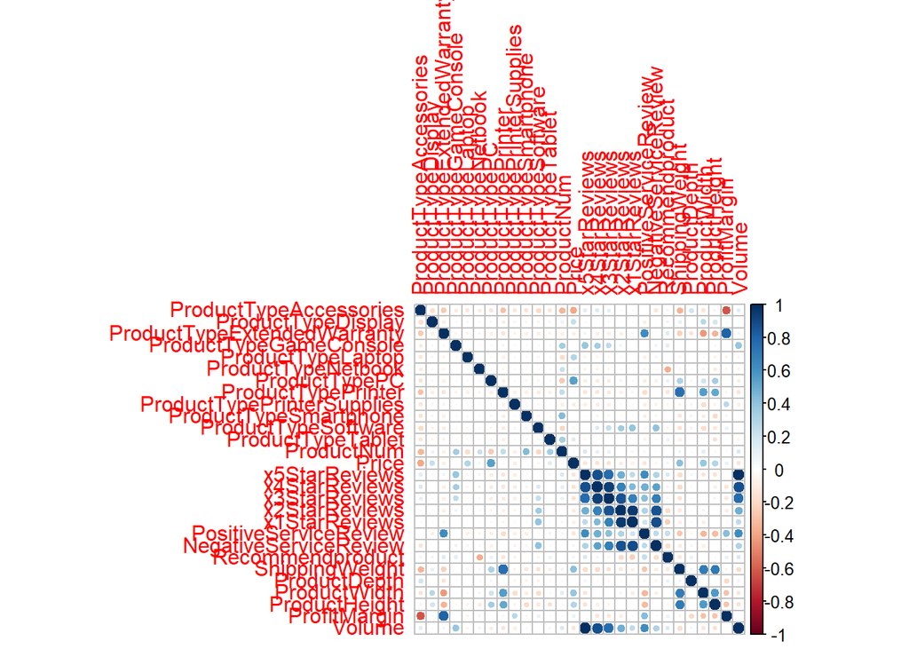

```r
corrplot(corrData)
```

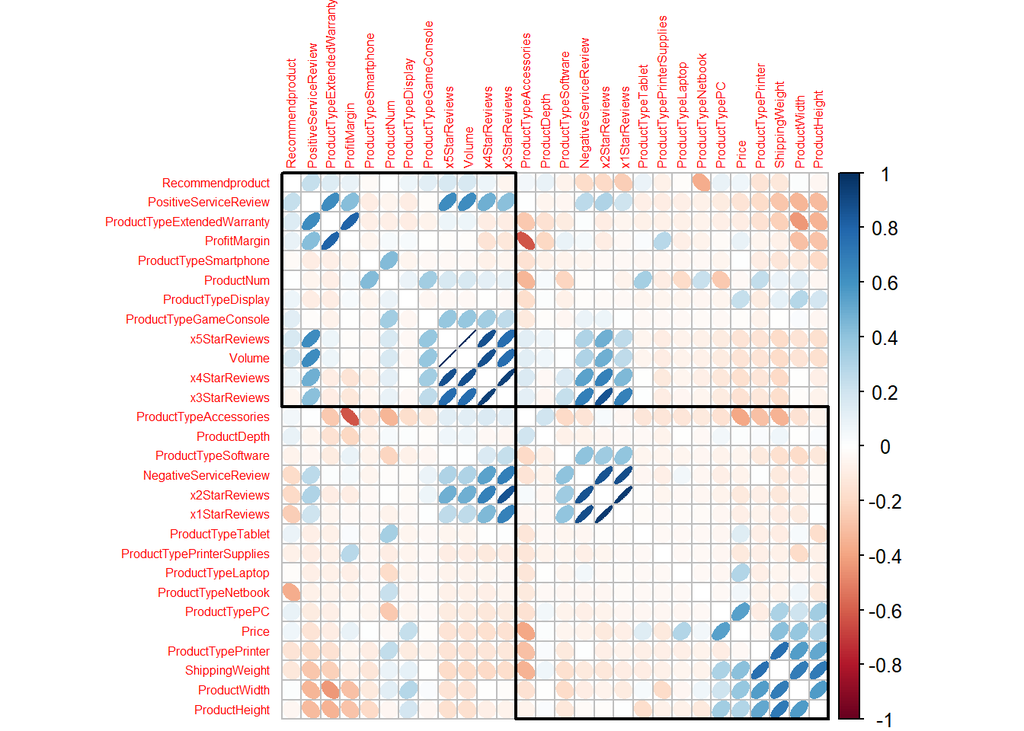

```r
corrplot(corrData, method = "ellipse",
         tl.cex = 0.5,
         order = "hclust",     # groups correlated vars together
         addrect = 2,          # adds rectangles around clusters
         diag = FALSE)         # remove diagonal for clarity)
```

Correlation Analysis;

# 10 EDA

# 11 Univariant

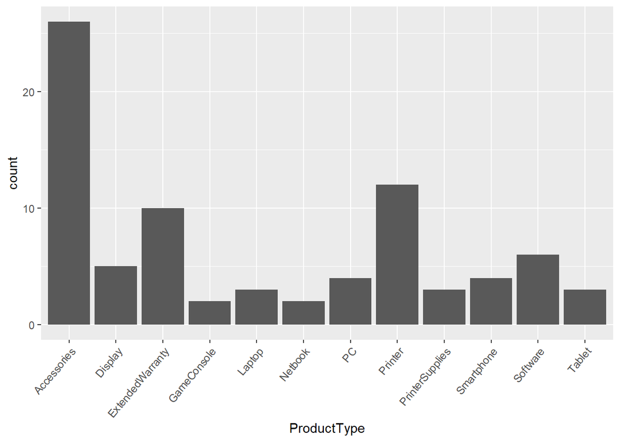

```r
d <- ggplot(Sales, aes(ProductType))
 d + geom_bar()  +
theme(axis.text.x = element_text(angle = 50, hjust = 1))
```

Univariate Insights;

# 12 Bivariant

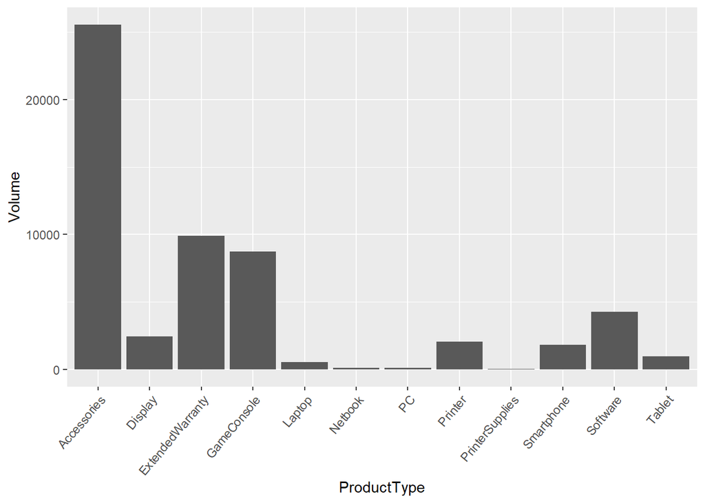

```r
m <- ggplot(Sales, aes(ProductType, Volume))
 m + geom_col() +
theme(axis.text.x = element_text(angle = 50, hjust = 1))
```

Insight; The productType with the highest Volume is the “Accessories” with an outragious outliers, while the ProductType with the least volume is “PrinterSupplies,PC and Notebook”

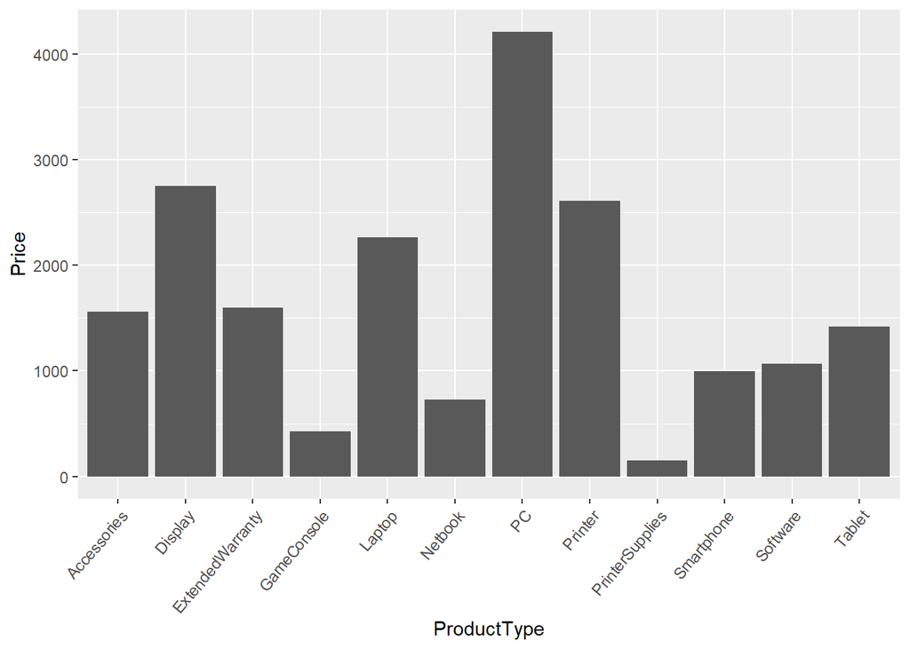

```r
f <- ggplot(Sales, aes(ProductType, Price))
 f + geom_col() +
theme(axis.text.x = element_text(angle = 50, hjust = 1))
```

Insight; The ProdutType with the highest price is the “PC”, while productType with the least price is the “PrinterSupplies”.

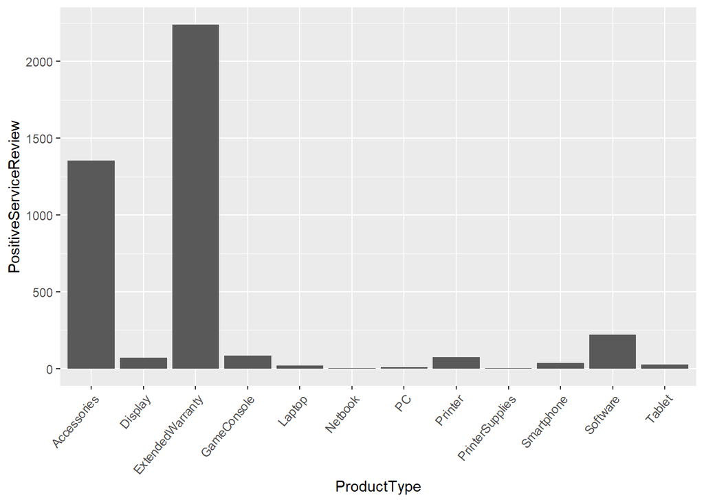

```r
g<- ggplot(Sales, aes(ProductType, PositiveServiceReview))
 g + geom_col() +
theme(axis.text.x = element_text(angle = 50, hjust = 1))
```

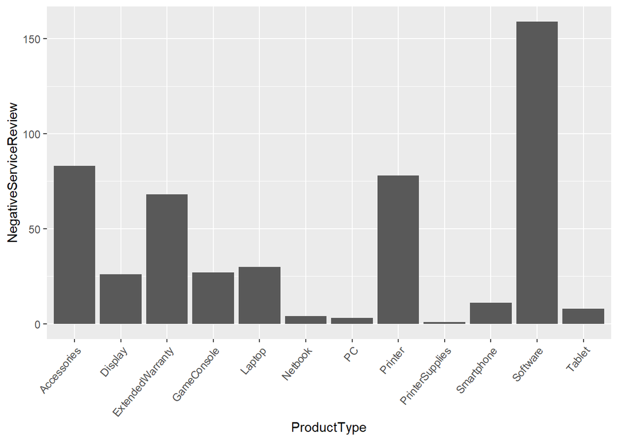

```r
h<- ggplot(Sales, aes(ProductType, NegativeServiceReview))
 h + geom_col() +
theme(axis.text.x = element_text(angle = 50, hjust = 1))
```

Insight The productType with the highest Negative service review is the “Software”, while the productType with the least are “Printersupplies, PC, and Netbook”.

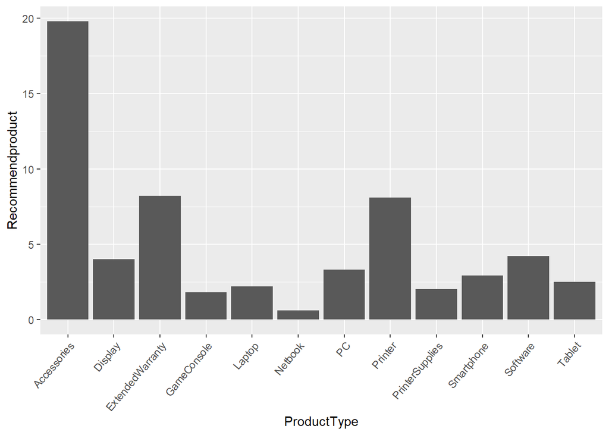

```r
i<- ggplot(Sales, aes(ProductType, Recommendproduct))
 i + geom_col() +
theme(axis.text.x = element_text(angle = 50, hjust = 1))
```

Insight The highest most recommended product Type is the “Accessories”, while the least recommended is the “Netbook”.

```
## Smoothing formula not specified. Using: y ~ x
```

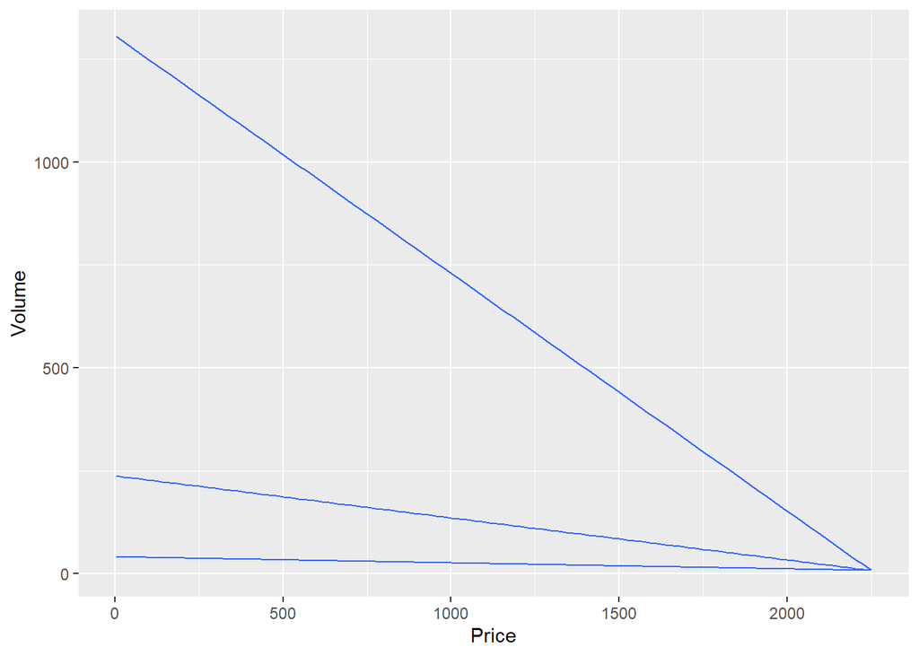

```r
k <- ggplot(Sales, aes(Price, Volume))
k + geom_quantile()
```

```
## Smoothing formula not specified. Using: y ~ x
```

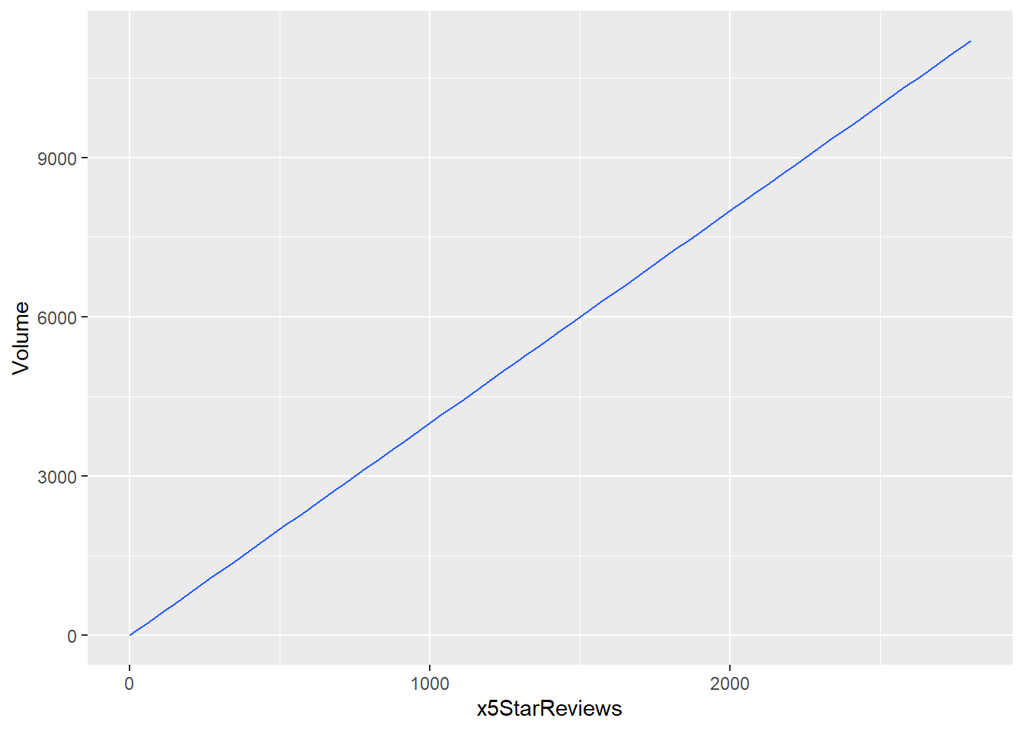

```r
b <- ggplot(Sales, aes(x5StarReviews, Volume))
b + geom_quantile()
```

```
## Smoothing formula not specified. Using: y ~ x
```

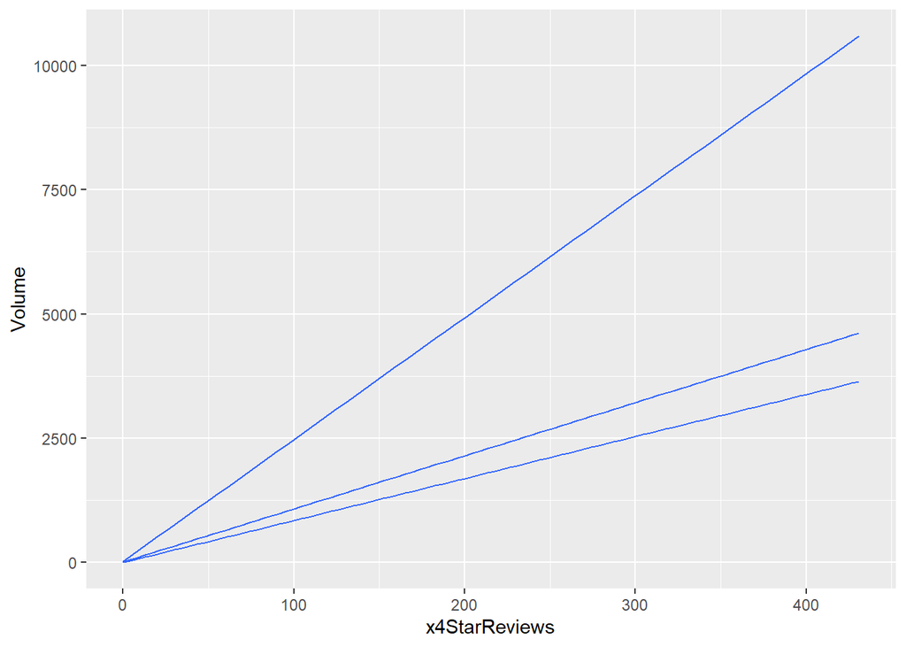

```r
j <- ggplot(Sales, aes(x4StarReviews, Volume))
j + geom_quantile()
```

```
## Smoothing formula not specified. Using: y ~ x
```

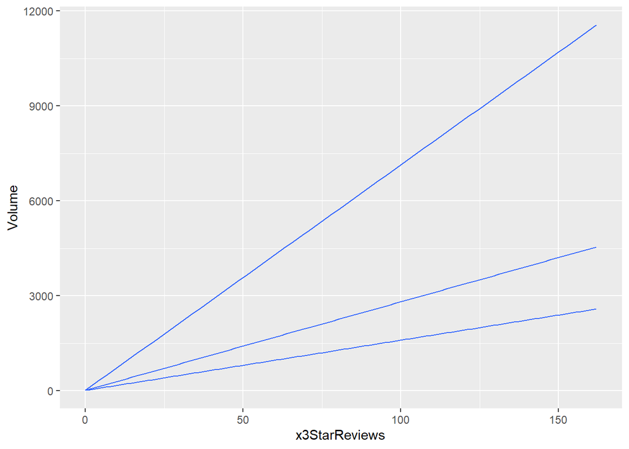

```r
a <- ggplot(Sales, aes(x3StarReviews, Volume))
a + geom_quantile()
```

```
## Smoothing formula not specified. Using: y ~ x
```

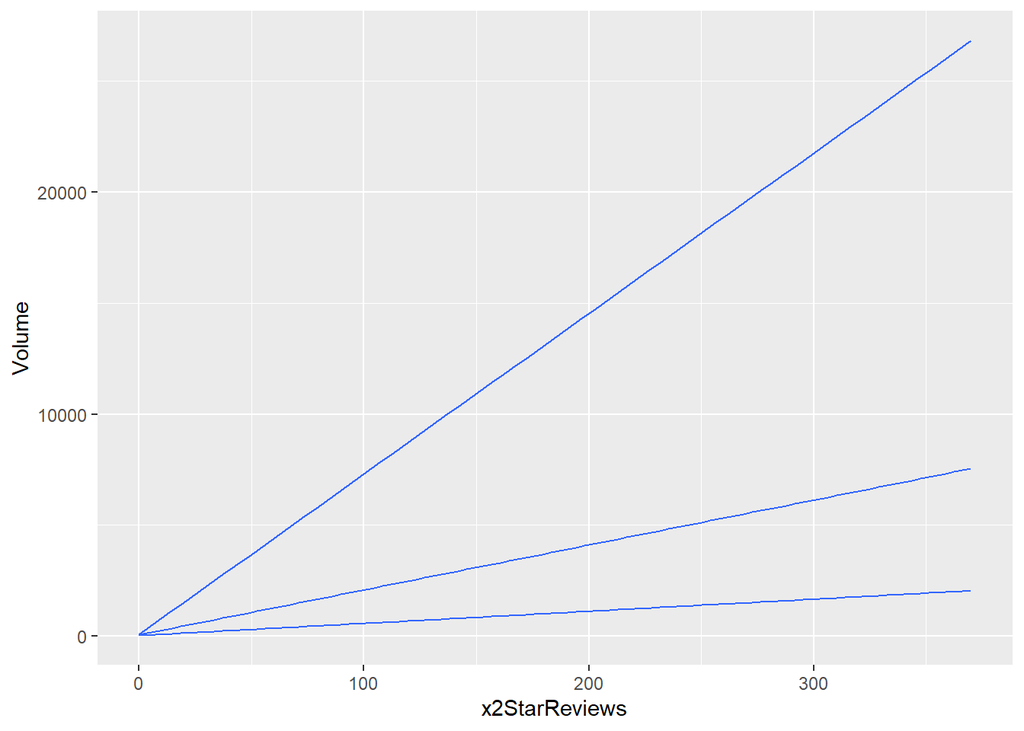

```r
c <- ggplot(Sales, aes(x2StarReviews, Volume))
c + geom_quantile()
```

```
## Smoothing formula not specified. Using: y ~ x
```

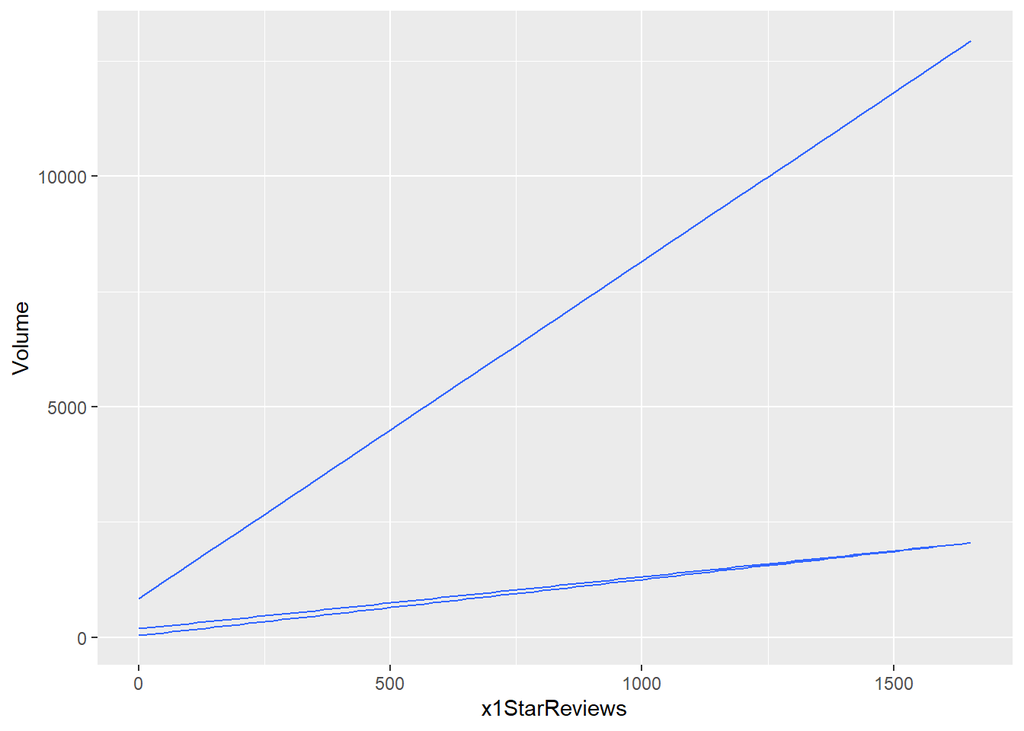

```r
e <- ggplot(Sales, aes(x1StarReviews, Volume))
e + geom_quantile()
```

Bivariate Insights

1. Accessories also had the highest sales volume, although with notable outliers.
2. PCs had the highest product price range.
3. Software had the highest negative service reviews.
4. Accessories had the highest positive recommendations.

# 13 Multivariant

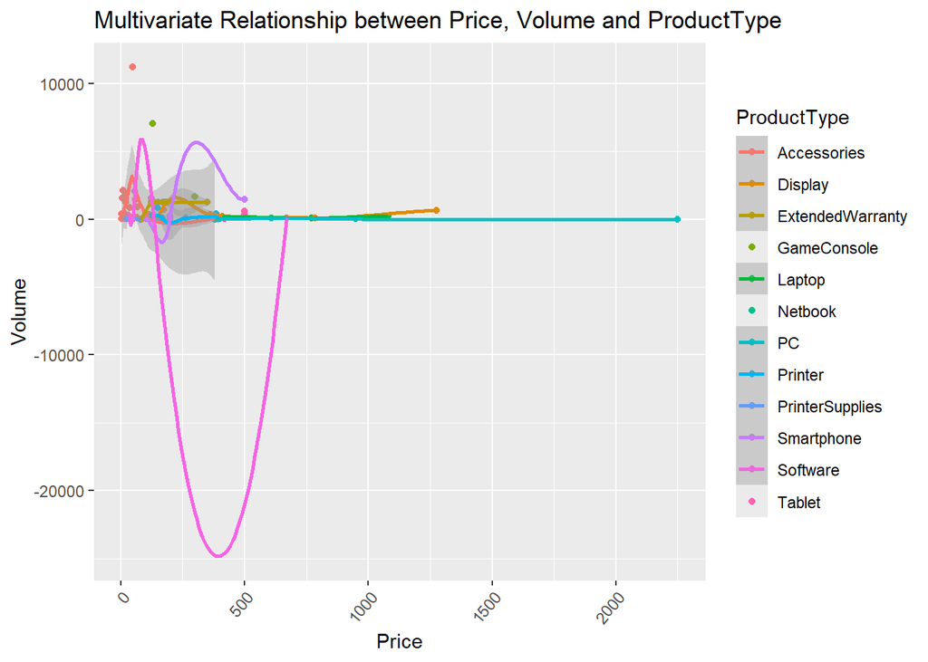

```r
#boxplot of salary and brand
ggplot (Sales,aes (x=Price, y=Volume, col=ProductType)) +
geom_point() +
theme(axis.text.x = element_text(angle = 50, hjust = 1)) +
geom_smooth() +
  labs( X = 'Price', Y = "Volume", title= "Multivariate Relationship between Price, Volume and ProductType")
```

Multivariate Insights;

A multivariate plot of Price vs Volume colored by ProductType showed:

1. Different product types respond differently to price changes.
2. Some categories have strong price–volume relationships, others much weaker.

```r
set.seed(3456)
trainIndex <- createDataPartition(Sales$Volume, p = .8,
                                  list = FALSE,
                                  times = 1)
head(trainIndex)
```

```
##      Resample1
## [1,]         1
## [2,]         3
## [3,]         4
## [4,]         5
## [5,]         6
## [6,]         7
```

```r
trainset <- Sales[trainIndex,]
testset <- Sales[-trainIndex,]
```

Predictive Modeling

The dataset was split into:

1. Training set: 80%
2. Test set: 20%

```r
trainset
```

```
##         ProductType ProductNum   Price x5StarReviews x4StarReviews
## 1                PC        101  949.00             3             3
## 3                PC        103  399.00             3             0
## 4            Laptop        104  409.99            49            19
## 5            Laptop        105 1079.99            58            31
## 6       Accessories        106  114.22            83            30
## 7       Accessories        107  379.99            11             3
## 8       Accessories        108   65.29            33            19
## 9       Accessories        109  119.99            16             9
## 12      Accessories        112   15.00            75            25
## 13      Accessories        113   52.50            10             8
## 14      Accessories        114   21.08           313            62
## 16      Accessories        116    3.60             8             6
## 17      Accessories        117    3.60            11             5
## 18      Accessories        118  174.99           170           100
```

[output cut: 249 more lines]

```r
testset
```

```
##        ProductType ProductNum   Price x5StarReviews x4StarReviews x3StarReviews
## 2               PC        102 2249.99             2             1             0
## 10     Accessories        110   16.99            10             1             1
## 11     Accessories        111    6.55            21             2             2
## 15     Accessories        115   18.98           349           118            27
## 20        Software        120  670.00            20             2             4
## 25        Software        125   31.99            77            31             7
## 28         Printer        128  262.98            22             8             3
## 30 PrinterSupplies        130   26.78             6             2             0
## 45     Accessories        145    6.99           384            31            13
## 48     Accessories        148   10.75           535           261           134
## 53     Accessories        153   19.99           474            38             7
## 69         Printer        169  385.96            99            43            17
## 71          Tablet        185  499.00           148            66            30
## 72      Smartphone        190  199.00             4             1             0
```

[output cut: 49 more lines]

## 13.1 Creating/building your model

```r
## base parameter tuning
fitControl <- trainControl(## 10-fold CV
  method = "repeatedcv",
  number = 10,
  ## repeated ten times
  repeats = 10)
```

## 13.2 gbm method

```r
gbmFit1 <- train(Volume ~ x5StarReviews + x3StarReviews + x2StarReviews + x1StarReviews + PositiveServiceReview + NegativeServiceReview, data = trainset,
                 method = "gbm",
                 trControl = fitControl,
                 ## This last option is actually one
                 ## for gbm() that passes through
                 verbose = FALSE, )

gbmFit1
```

```
## Stochastic Gradient Boosting
##
## 65 samples
##  6 predictor
##
## No pre-processing
## Resampling: Cross-Validated (10 fold, repeated 10 times)
## Summary of sample sizes: 57, 58, 58, 58, 61, 59, ...
## Resampling results across tuning parameters:
##
##   interaction.depth  n.trees  RMSE      Rsquared   MAE
##   1                   50      916.8905  0.8596902  522.4417
##   1                  100      954.0825  0.8403375  547.6375
##   1                  150      966.5379  0.8213587  550.6749
##   2                   50      934.8810  0.8554955  527.9830
##   2                  100      955.7133  0.8306530  544.3705
##   2                  150      986.1560  0.8051720  566.7482
##   3                   50      904.2145  0.8537386  508.6439
##   3                  100      948.9077  0.8335186  545.6307
##   3                  150      981.9606  0.8127440  568.1245
##
## Tuning parameter 'shrinkage' was held constant at a value of 0.1
##
## Tuning parameter 'n.minobsinnode' was held constant at a value of 10
## RMSE was used to select the optimal model using the smallest value.
## The final values used for the model were n.trees = 50, interaction.depth =
##  3, shrinkage = 0.1 and n.minobsinnode = 10.
```

## 13.3 Random forest model

```r
rfFit1 <- train(Volume ~ x5StarReviews + x3StarReviews + x2StarReviews + x1StarReviews + PositiveServiceReview + NegativeServiceReview, data = trainset,
                 method = "rf",
                 trControl = fitControl,
                 ## This last option is actually one
                 ## for gbm() that passes through
                 verbose = FALSE, )

rfFit1
```

```
## Random Forest
##
## 65 samples
##  6 predictor
##
## No pre-processing
## Resampling: Cross-Validated (10 fold, repeated 10 times)
## Summary of sample sizes: 60, 59, 59, 59, 58, 58, ...
## Resampling results across tuning parameters:
##
##   mtry  RMSE      Rsquared   MAE
##   2     696.7254  0.9359943  324.1327
##   4     615.2925  0.9625367  275.2524
##   6     572.5526  0.9710869  250.6320
##
## RMSE was used to select the optimal model using the smallest value.
## The final value used for the model was mtry = 6.
```

## 13.4 Pls method

```r
plsFit1 <- train(Volume ~ x5StarReviews + x3StarReviews + x2StarReviews + x1StarReviews + PositiveServiceReview + NegativeServiceReview, data = trainset,
                 method = "pls",
                 trControl = fitControl,
                 ## This last option is actually one
                 ## for pls() that passes through
                 verbose = FALSE, )

plsFit1
```

```
## Partial Least Squares
##
## 65 samples
##  6 predictor
##
## No pre-processing
## Resampling: Cross-Validated (10 fold, repeated 10 times)
## Summary of sample sizes: 58, 60, 59, 60, 57, 59, ...
## Resampling results across tuning parameters:
##
##   ncomp  RMSE       Rsquared   MAE
##   1      93.141027  0.9960984  58.86613
##   2      64.897129  0.9966117  38.82438
##   3       3.364601  0.9999820   1.85688
##
## RMSE was used to select the optimal model using the smallest value.
## The final value used for the model was ncomp = 3.
```

*Final Model Selection

1. Interpretability
2. Reduced dimensionality
3. Consistency across cross-validation repeats

```r
resamps_volume <- resamples(list(rf = rfFit1, gbm = gbmFit1, pls = plsFit1))
summary(resamps_volume)
```

```
##
## Call:
## summary.resamples(object = resamps_volume)
##
## Models: rf, gbm, pls
## Number of resamples: 100
##
## MAE
##            Min.     1st Qu.     Median      Mean    3rd Qu.       Max. NA's
## rf    3.0555733  20.3064097  44.354892 250.63197 410.350757 2174.86328    0
## gbm 110.7378056 278.3536243 360.055542 508.64387 492.145952 2256.35794    0
## pls   0.4171837   0.7542022   1.028837   1.85688   1.904532   11.92195    0
##
## RMSE
##            Min.    1st Qu.     Median       Mean    3rd Qu.       Max. NA's
## rf    3.5551550  36.370905  81.172127 572.552568 940.959024 4142.13703    0
## gbm 148.0185869 386.823412 476.928336 904.214479 674.903067 4300.49745    0
## pls   0.5344391   0.846866   1.420012   3.364601   3.275619   27.62494    0
##
## Rsquared
##          Min.   1st Qu.    Median      Mean   3rd Qu.      Max. NA's
## rf  0.8202242 0.9714455 0.9874611 0.9710869 0.9968108 0.9999510    0
## gbm 0.4249728 0.8042423 0.8947760 0.8537386 0.9514985 0.9994113    0
## pls 0.9998242 0.9999826 0.9999980 0.9999820 0.9999993 1.0000000    0
```

## 13.5 Building final Model using PLS

```r
plsGrid <- expand.grid(ncomp = 3)

nrow(plsGrid)
```

```
## [1] 1
```

```r
plsFitfinal <- train(Volume ~ x5StarReviews + x3StarReviews + x2StarReviews + x1StarReviews + PositiveServiceReview + NegativeServiceReview, data = trainset,
                 method = "pls",
                 trControl = fitControl,
                 ## This last option is actually one
                 ## for pls() that passes through
                 verbose = FALSE,
                 tuneGrid = plsGrid)


plsFitfinal
```

```
## Partial Least Squares
##
## 65 samples
##  6 predictor
##
## No pre-processing
## Resampling: Cross-Validated (10 fold, repeated 10 times)
## Summary of sample sizes: 60, 59, 57, 60, 57, 60, ...
## Resampling results:
##
##   RMSE      Rsquared  MAE
##   3.203816  0.999985  1.799722
##
## Tuning parameter 'ncomp' was held constant at a value of 3
```